# Breareal

[Hjem](https://ninanor.github.io/IBECA) | [Økosystem Fjell](https://ninanor.github.io/IBECA/fjell)

[figure not shown]

| [Økosystem Skog](https://ninanor.github.io/IBECA/skog)

[figure not shown]

| [Faktaark](https://ninanor.github.io/IBECA/faktaark) |

# Analyser av breareal

## Importerer data

### Breatlas

Her er det nye breatlasset med breareal fra 2018 og 2019 hentet fra Sentinell (ref Liss Marie Andreassen, NVE)

```r
breatlas <- sf::st_read('/data/P-Prosjekter/41201042_okologisk_tilstand_fastlandsnorge_2020_dataanaly/fjell2021/data/breatlas/breatlas_2018_2019/Breatlas_20182019_temp20210922_lma.shp')
```

CRS: UTM 33N ETRS89 Det er 6915 polygoner

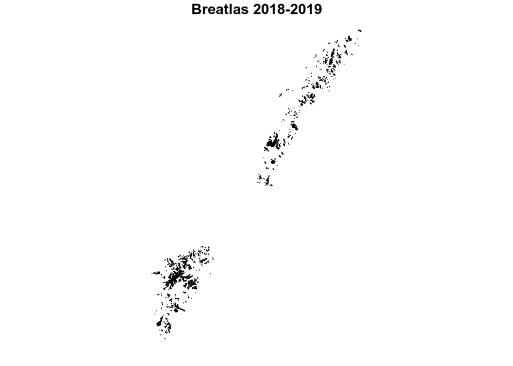

```r
plot(breatlas[1], main = "Breatlas 2018-2019", col = "black")
```

Arealet ser større ut en det er fordi det er lagt på kantlinjer.

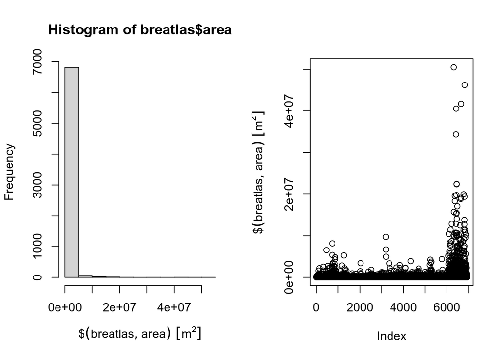

```r
breatlas$area <- st_area(breatlas)
par(mfrow=c(1,2))
hist(breatlas$area)
plot(breatlas$area)
```

De fleste polygonene er små. Og så er det noen få veldig store. Den største er 50 km2.

### Kart over Norge

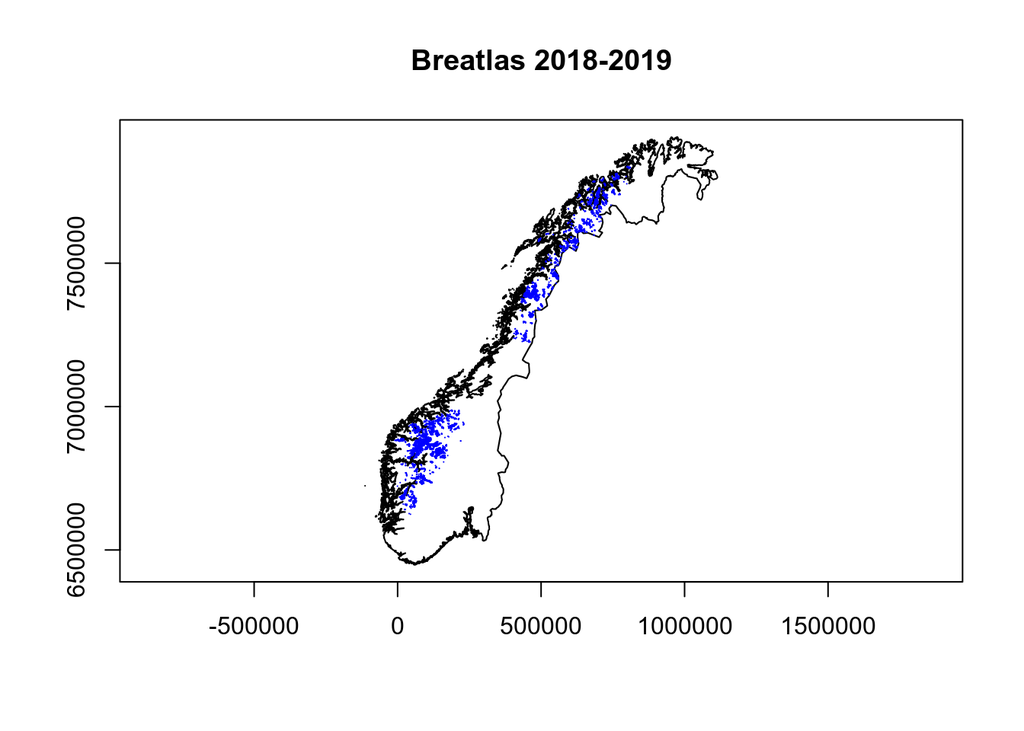

```r
nor <- readRDS('../data/norway_outline.RDS')%>%
  st_as_sf()%>%
  st_transform(crs=crs(breatlas))
plot(nor$geometry, axes=T, main = "Breatlas 2018-2019")
  plot(breatlas$geometry, add=T, border = "blue")
```

UTM33 WGS84

### N50

Her er utstrekningen til breer i perioden 1952 til 1985, basert på gamle kart.

```r
n50 <- sf::st_read('/data/P-Prosjekter/41201042_okologisk_tilstand_fastlandsnorge_2020_dataanaly/fjell2021/data/breatlas/n50/cryoclim_GAO_NO_1952_1985_UTM_33N.shp')%>%
  st_transform(crs = crs(breatlas))
```

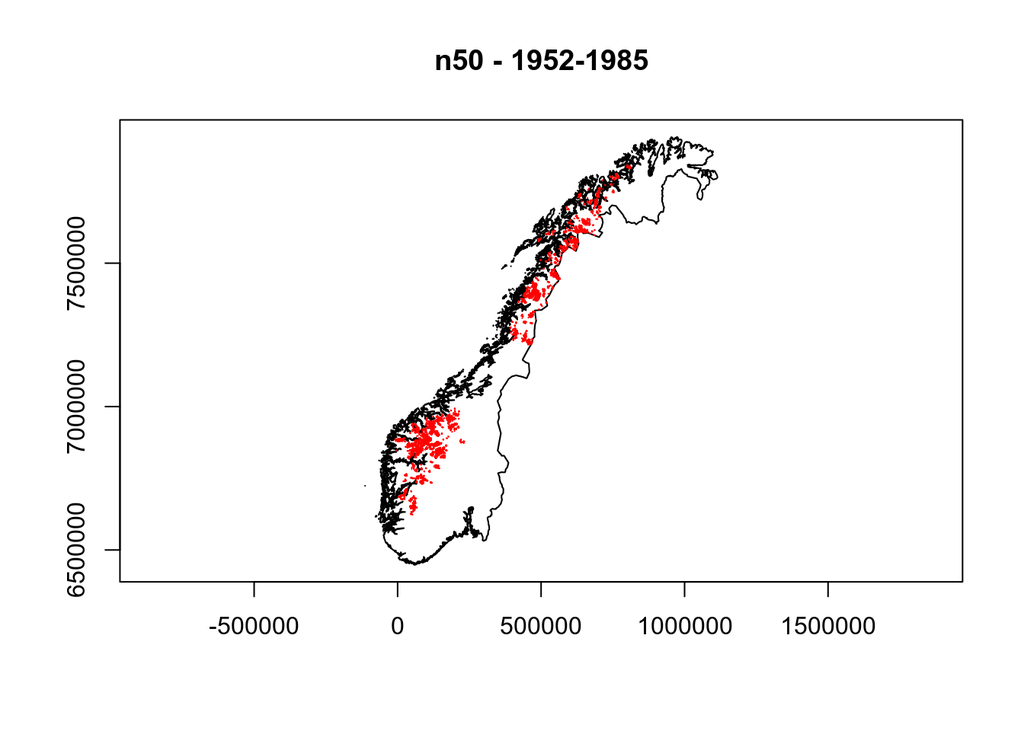

```r
plot(nor$geometry, axes=T, main = "n50 - 1952-1985")
  plot(n50$geometry, add=T, border = "red")
```

La oss plotte alt sammen oppå hverandre

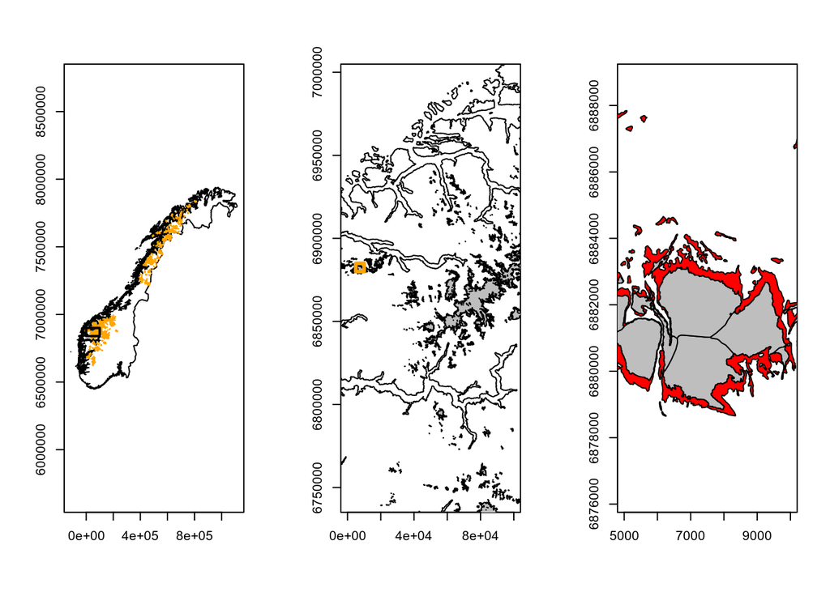

```r
myExt <- raster::extent(c(0, 100000, 6840000, 6900000))
myExt2 <- raster::extent(c(5000, 10000, 6880000, 6885000))

par(mfrow=c(1,3))
plot(nor$geometry, axes=T)
    plot(n50$geometry,  border = "orange", col = scales::alpha("orange", 1), add=T)
    plot(myExt, add=T, lwd=2)

plot(nor$geometry, xlim=c(0, 100000),
          ylim=c(6840000, 6900000),
          axes=T)
    plot(n50$geometry, add=T, col = "grey")
    plot(myExt2, add=T, lwd=3, col="orange")

plot(nor$geometry, xlim=c(5000, 10000),
          ylim=c(6880000, 6885000),
     axes=T)
    plot(n50$geometry, add=T, col = "red")
    plot(breatlas$geometry, add=T, col = "grey")
```

De røde områdene i kartet til høyre er hvor isen har trekt seg tilbake. Nå må vi dele kartlage inn etter regioner for så å sammenligne arealet i n50 med breatlaset. Hvordan vi gjør det med kalkulering av usikkerhet vet jeg fortsatt ikke.

### Regioner

Henter shp med regionene

```r
reg <- st_read("/data/P-Prosjekter/41201042_okologisk_tilstand_fastlandsnorge_2020_dataanaly/FINAL/Raw_data/Geografisk_oppdeling/regioner_2010/regNorway_wgs84 - MERGED.shp")%>%
  st_transform(crs = crs(breatlas))
```

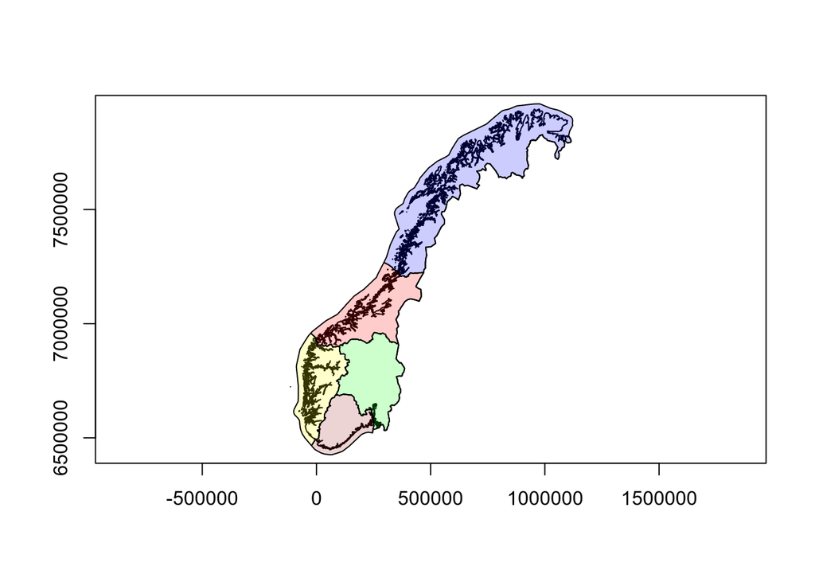

```r
plot(nor$geometry, axes=T)
  plot(reg$geometry, add=T, border = "black",
       col = scales::alpha(c("blue",
                             "red",
                             "green",
                             "yellow",
                             "brown"), .2))
```

Før vi henter brearealet inn i tabellen for regionene må jeg prøve å fikse et problem med noen brepolygoner som krysser seg selv

```r
table(st_is_valid(breatlas))
```

```
##
## FALSE  TRUE
##    68  6847
```

```r
st_is_valid(breatlas, reason=T)[1:10]
```

```
##  [1] "Valid Geometry"
##  [2] "Valid Geometry"
##  [3] "Valid Geometry"
##  [4] "Valid Geometry"
##  [5] "Valid Geometry"
##  [6] "Valid Geometry"
##  [7] "Valid Geometry"
##  [8] "Valid Geometry"
##  [9] "Ring Self-intersection[100236.4931 6912507.5864]"
## [10] "Valid Geometry"
```

```r
# krever lwgeom
breatlas2 <- st_make_valid(breatlas)
table(st_is_valid(breatlas2))
```

```
##
## TRUE
## 6915
```

```r
# samme resultat:
#breatlas2 <- st_buffer(breatlas, 0.0)
#table(st_is_valid(breatlas2))
```

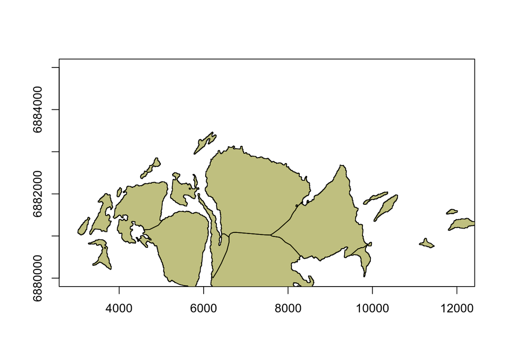

```r
plot(nor$geometry, xlim=c(5000, 10000),
          ylim=c(6880000, 6885000),
     axes=T)
    plot(breatlas2$geometry, add=T, col = scales::alpha("blue",0.5))
    plot(breatlas$geometry, add=T, col = scales::alpha("yellow",0.5))
```

Dette ser ut til å ha funket fint. Denne litt kunstige inndelingen av tilgrensende polygoner er forresten bare i det nye breatlaset, ikke i n50.

```r
breatlas <- breatlas2
rm(breatlas2)
```

```r
unique(reg$region)
```

```
## [1] "Nord-Norge"      "Midt-Norge"      "Ã\u0098stlandet" "Vestlandet"
## [5] "SÃ¸rlandet"
```

Fikser øæå

```r
reg$region[reg$region=="Ã\u0098stlandet"] <- "Østlandet"
reg$region[reg$region=="SÃ¸rlandet"] <- "Sørlandet"
```

## Breareal per region

### Dagens breer

Her er en metode for å finne breareal per region.

```r
brealtas_reg <- st_intersection(breatlas, reg)
```

Skjekker hva som skjer med breer som ligger midt mellom to regioner

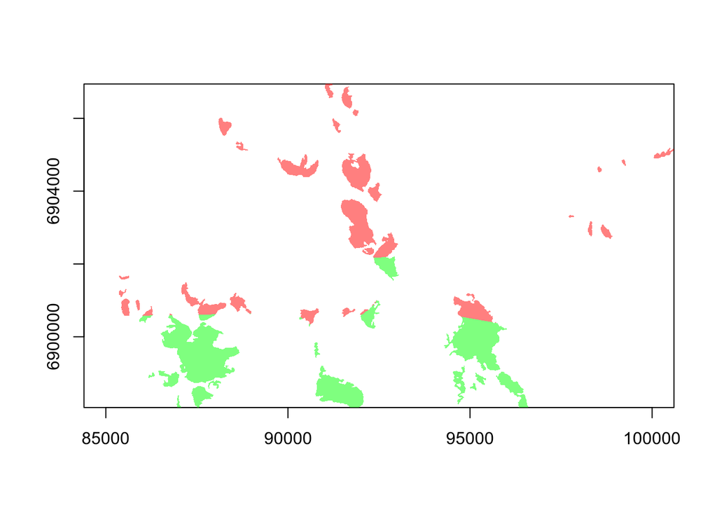

```r
plot(brealtas_reg$geometry[brealtas_reg$region=="Midt-Norge"],
    col = scales::alpha("red",0.5), border=NA, axes=T,
     ylim=c(6900000, 6905000),
     xlim=c(85000, 100000))
plot(brealtas_reg$geometry[brealtas_reg$region=="Vestlandet"],
     col = scales::alpha("green",0.5), border=NA, add=T)
  plot(nor$geometry, add=T)
```

Det deler polygonene ved grensen. Det er bra

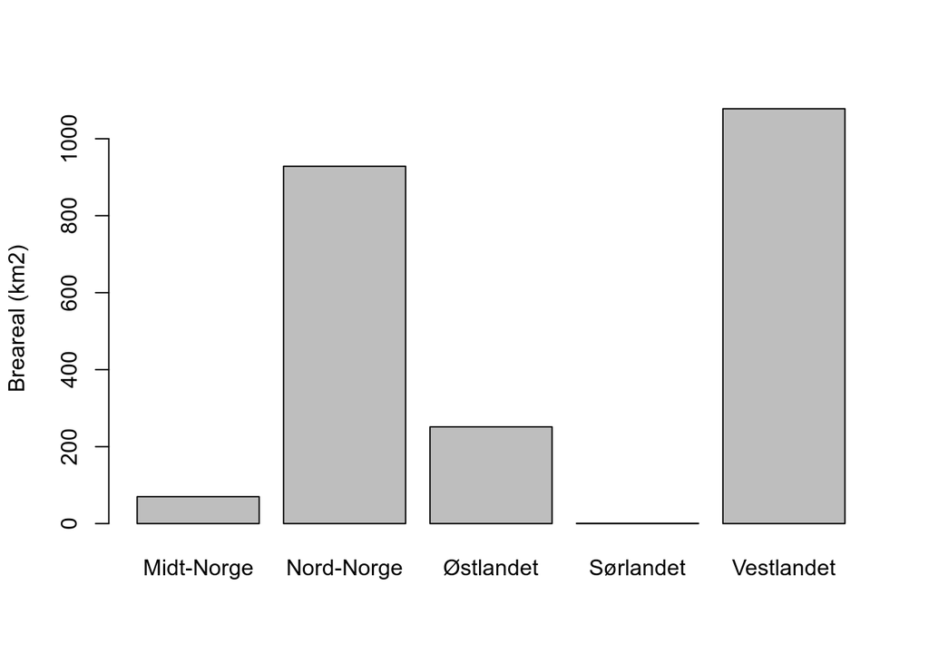

```r
brealtas_reg$area_crop <- st_area(brealtas_reg)

bretabell <- tapply(
       brealtas_reg$area_crop,
       brealtas_reg$region,
       FUN = sum)
bretabell <- bretabell/1000000
barplot(
  bretabell,
  ylab="Breareal (km2)"
)
```

### Samme for N50

```r
n50x <- st_make_valid(n50)
n50_reg <- st_intersection(n50x, reg)
```

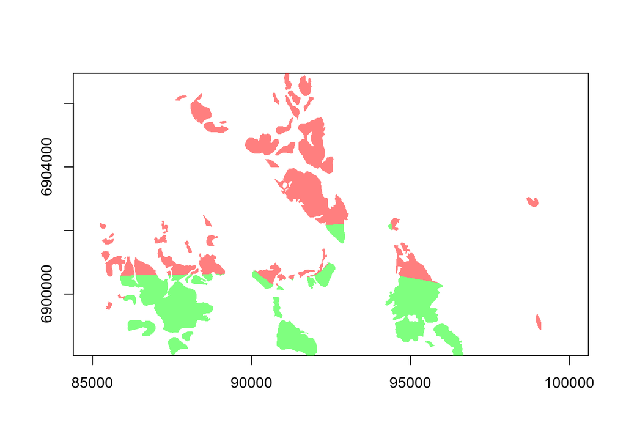

```r
plot(n50_reg$geometry[n50_reg$region=="Midt-Norge"],
    col = scales::alpha("red",0.5), border=NA, axes=T,
     ylim=c(6900000, 6905000),
     xlim=c(85000, 100000))
plot(n50_reg$geometry[n50_reg$region=="Vestlandet"],
     col = scales::alpha("green",0.5), border=NA, add=T)
  plot(nor$geometry, add=T)
```

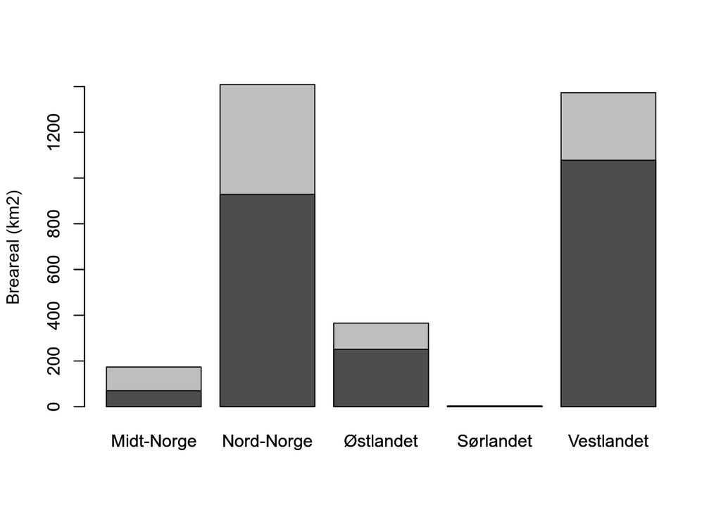

```r
n50_reg$area_crop <- st_area(n50_reg)

n50tabell <- tapply(
       n50_reg$area_crop,
       n50_reg$region,
       FUN = sum)
n50tabell <- n50tabell/1000000


barplot(
  n50tabell,
  ylab="Breareal (km2)",
  col="grey"
)
barplot(
  bretabell,
  ylab="Breareal (km2)",
  add=T,
  col="grey30"
)
```

## Skalerte verdier

```r
myTbl <- tibble(region          = names(bretabell),
                indikator        = bretabell,
                referanseverdi   = n50tabell)
myTbl$skalert_indikator <- myTbl$indikator/myTbl$referanseverdi
```

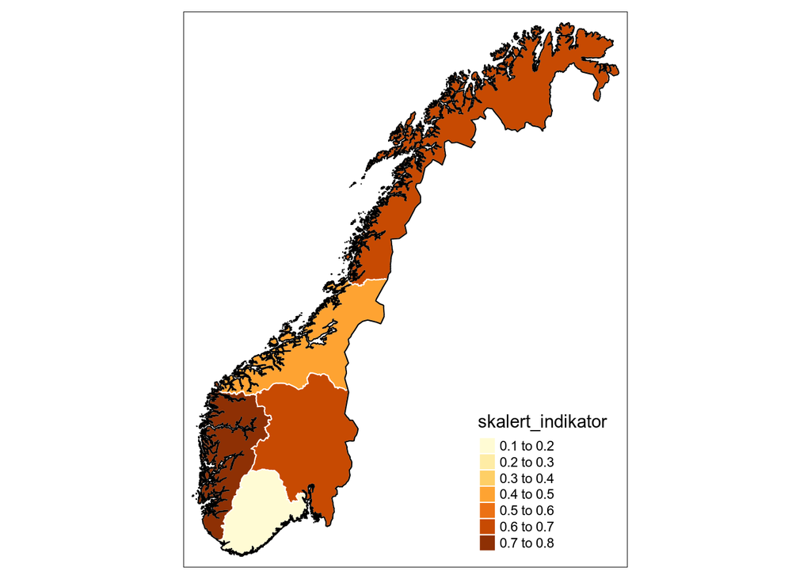

```r
reg$skalert_indikator <- myTbl$skalert_indikator[match(reg$region, myTbl$region)]
reg_clipped <- st_intersection(reg, nor)
tm_shape(reg_clipped) +
  tm_polygons(col="skalert_indikator", border.col = "white")+
  tm_shape(nor)+
  tm_polygons(alpha = 0,border.col = "black")
```

Det er 3 måter å kalkulere den nasjonale indikatorverdien på:

1. ta gjennomsnitt av de skalerte regionale indikatorverdiene og la alle regoinene telle likt (regional skaleringsmetode)

```r
mean(reg_clipped$skalert_indikator)
```

```
## [1] 0.5445936
```

2. summer indikatorverdien for hele landet og del på den summerte referanseverdien for hele landet (nasjonal metode)

```r
mean(bretabell)/mean(n50tabell)
```

```
## [1] 0.7003536
```

3. summere skalerte regionale indikatorverdier etter å ha gitt de ulike vekt grunnet areal (arealveid metode)

```r
reg_clipped$areal <- st_area(reg_clipped$geometry)/1000000

totalArea <- sum(reg_clipped$areal)

reg_clipped$skalert_indikator_v <- reg_clipped$skalert_indikator*
  reg_clipped$areal


sumSkalerteIndikatorer <- sum(reg_clipped$skalert_indikator_v)

sumSkalerteIndikatorer/totalArea
```

```
## 0.5884451 [1]
```